# Start-Up Success

mswartz

2024-03-24

## Introduction

```r
library(readxl) # Read excel files
library(ggplot2) # Visualizations
library(dplyr) # Data manipulation
library(corrplot) # Correlation matrices
library(caret) # Machine learning
library(lubridate) # Dates and times
library(skimr)  # An automated EDA tool
library(stats) # Stat functions
library(tidyr)
library(car)
library(rpart.plot)
library(randomForest)
```

## Reading Excel files

```r
start_up <- read_excel("StartupDataCleanedR.xlsx")
```

## Data Prep

```r
summary(start_up)
```

```
##   state_code           latitude       longitude         zip_code
##  Length:923         Min.   :25.75   Min.   :-122.76   Length:923
##  Class :character   1st Qu.:37.39   1st Qu.:-122.20   Class :character
##  Mode  :character   Median :37.78   Median :-118.37   Mode  :character
##                     Mean   :38.52   Mean   :-103.54
##                     3rd Qu.:40.73   3rd Qu.: -77.21
##                     Max.   :59.34   Max.   :  18.06
##
##       id                city               name               labels
##  Length:923         Length:923         Length:923         Min.   :0.0000
##  Class :character   Class :character   Class :character   1st Qu.:0.0000
##  Mode  :character   Mode  :character   Mode  :character   Median :1.0000
##                                                           Mean   :0.6468
##                                                           3rd Qu.:1.0000
##                                                           Max.   :1.0000
##
##    founded_at                     founded_month       founded_year
##  Min.   :1984-01-01 00:00:00.00   Length:923         Min.   :1984
##  1st Qu.:2003-01-01 00:00:00.00   Class :character   1st Qu.:2003
##  Median :2006-01-01 00:00:00.00   Mode  :character   Median :2006
##  Mean   :2005-09-10 00:57:43.49                      Mean   :2005
##  3rd Qu.:2008-04-01 00:00:00.00                      3rd Qu.:2008
##  Max.   :2013-04-16 00:00:00.00                      Max.   :2013
##
##    closed_at                      first_funding_at
##  Min.   :2001-01-01 00:00:00.00   Min.   :2000-01-01 00:00:00.00
##  1st Qu.:2011-01-01 00:00:00.00   1st Qu.:2006-03-01 00:00:00.00
##  Median :2012-02-17 00:00:00.00   Median :2007-09-01 00:00:00.00
##  Mean   :2011-10-10 01:47:27.75   Mean   :2007-12-05 01:05:31.52
##  3rd Qu.:2013-01-13 00:00:00.00   3rd Qu.:2009-11-01 00:00:00.00
##  Max.   :2013-10-30 00:00:00.00   Max.   :2013-11-20 00:00:00.00
##  NA's   :588
##  last_funding_at                  age_first_funding_year age_last_funding_year
##  Min.   :2001-01-01 00:00:00.00   Min.   :-9.0466        Min.   :-9.047
##  1st Qu.:2008-01-01 00:00:00.00   1st Qu.: 0.5767        1st Qu.: 1.670
##  Median :2009-12-16 00:00:00.00   Median : 1.4466        Median : 3.529
##  Mean   :2009-08-15 00:31:12.16   Mean   : 2.2356        Mean   : 3.931
##  3rd Qu.:2011-04-29 00:00:00.00   3rd Qu.: 3.5753        3rd Qu.: 5.560
##  Max.   :2013-11-20 00:00:00.00   Max.   :21.8959        Max.   :21.896
##
```

[output cut: 57 more lines]

```
##  Min.   :0.0000   Min.   :0.00000   Min.   : 1.000   Min.   :0.0000
##  1st Qu.:0.0000   1st Qu.:0.00000   1st Qu.: 1.500   1st Qu.:1.0000
##  Median :0.0000   Median :0.00000   Median : 2.500   Median :1.0000
##  Mean   :0.2329   Mean   :0.09967   Mean   : 2.839   Mean   :0.8093
##  3rd Qu.:0.0000   3rd Qu.:0.00000   3rd Qu.: 3.800   3rd Qu.:1.0000
##  Max.   :1.0000   Max.   :1.00000   Max.   :16.000   Max.   :1.0000
##
##     status           is_acquired       is_closed
##  Length:923         Min.   :0.0000   Min.   :0.0000
##  Class :character   1st Qu.:0.0000   1st Qu.:0.0000
##  Mode  :character   Median :1.0000   Median :0.0000
##                     Mean   :0.6468   Mean   :0.3532
##                     3rd Qu.:1.0000   3rd Qu.:1.0000
##                     Max.   :1.0000   Max.   :1.0000
##
```

```r
str(start_up)
```

```
## tibble [923 × 50] (S3: tbl_df/tbl/data.frame)
##  $ state_code              : chr [1:923] "CA" "CA" "CA" "CA" ...
##  $ latitude                : num [1:923] 42.4 37.2 32.9 37.3 37.8 ...
##  $ longitude               : num [1:923] -71.1 -122 -117.2 -122.1 -122.4 ...
##  $ zip_code                : chr [1:923] "92101" "95032" "92121" "95014" ...
##  $ id                      : chr [1:923] "c:6669" "c:16283" "c:65620" "c:42668" ...
##  $ city                    : chr [1:923] "San Diego" "Los Gatos" "San Diego" "Cupertino" ...
##  $ name                    : chr [1:923] "Bandsintown" "TriCipher" "Plixi" "Solidcore Systems" ...
##  $ labels                  : num [1:923] 1 1 1 1 0 0 1 1 1 1 ...
##  $ founded_at              : POSIXct[1:923], format: "2007-01-01" "2000-01-01" ...
##  $ founded_month           : chr [1:923] "January" "January" "March" "January" ...
##  $ founded_year            : num [1:923] 2007 2000 2009 2002 2010 ...
##  $ closed_at               : POSIXct[1:923], format: NA NA ...
##  $ first_funding_at        : POSIXct[1:923], format: "2009-04-01" "2005-02-14" ...
##  $ last_funding_at         : POSIXct[1:923], format: "2010-01-01" "2009-12-28" ...
```

[output cut: 36 more lines]

```r
skim(start_up)
```

Data summary

| Name | start_up |
| --- | --- |
| Number of rows | 923 |
| Number of columns | 50 |
| _______________________ |  |
| Column type frequency: |  |
| character | 9 |
| numeric | 37 |
| POSIXct | 4 |
| ________________________ |  |
| Group variables | None |

**Variable type: character**

| skim_variable | n_missing | complete_rate | min | max | empty | n_unique | whitespace |
| --- | --- | --- | --- | --- | --- | --- | --- |
| state_code | 0 | 1 | 2 | 2 | 0 | 35 | 0 |
| zip_code | 0 | 1 | 4 | 14 | 0 | 382 | 0 |
| id | 0 | 1 | 3 | 8 | 0 | 922 | 0 |
| city | 0 | 1 | 2 | 19 | 0 | 221 | 0 |
| name | 0 | 1 | 3 | 39 | 0 | 922 | 0 |
| founded_month | 0 | 1 | 3 | 9 | 0 | 12 | 0 |
| state_code.1 | 1 | 1 | 2 | 2 | 0 | 35 | 0 |
| category_code | 0 | 1 | 3 | 16 | 0 | 35 | 0 |
| status | 0 | 1 | 6 | 8 | 0 | 2 | 0 |

**Variable type: numeric**

| skim_variable | n_missing | complete_rate | mean | sd | p0 | p25 | p50 | p75 | p100 | hist |
| --- | --- | --- | --- | --- | --- | --- | --- | --- | --- | --- |
| latitude | 0 | 1.00 | 38.52 | 3.74 | 25.75 | 37.39 | 37.78 | 40.73 | 5.934e+01 | ▁▇▅▁▁ |
| longitude | 0 | 1.00 | -103.54 | 22.39 | -122.76 | -122.20 | -118.37 | -77.21 | 1.806e+01 | ▇▅▁▁▁ |
| labels | 0 | 1.00 | 0.65 | 0.48 | 0.00 | 0.00 | 1.00 | 1.00 | 1.000e+00 | ▅▁▁▁▇ |
| founded_year | 0 | 1.00 | 2005.50 | 3.53 | 1984.00 | 2003.00 | 2006.00 | 2008.00 | 2.013e+03 | ▁▁▂▇▅ |
| age_first_funding_year | 0 | 1.00 | 2.24 | 2.51 | -9.05 | 0.58 | 1.45 | 3.58 | 2.190e+01 | ▁▇▃▁▁ |
| age_last_funding_year | 0 | 1.00 | 3.93 | 2.97 | -9.05 | 1.67 | 3.53 | 5.56 | 2.190e+01 | ▁▇▇▁▁ |
| age_first_milestone_year | 152 | 0.84 | 3.06 | 2.98 | -14.17 | 1.00 | 2.52 | 4.69 | 2.468e+01 | ▁▃▇▁▁ |
| age_last_milestone_year | 152 | 0.84 | 4.75 | 3.21 | -7.01 | 2.41 | 4.48 | 6.75 | 2.468e+01 | ▁▇▅▁▁ |
| relationships | 0 | 1.00 | 7.71 | 7.27 | 0.00 | 3.00 | 5.00 | 10.00 | 6.300e+01 | ▇▂▁▁▁ |
| funding_rounds | 0 | 1.00 | 2.31 | 1.39 | 1.00 | 1.00 | 2.00 | 3.00 | 1.000e+01 | ▇▃▁▁▁ |
| funding_total_usd | 0 | 1.00 | 25419749.09 | 189634364.49 | 11000.00 | 2725000.00 | 10000000.00 | 24725000.00 | 5.700e+09 | ▇▁▁▁▁ |
| milestones | 0 | 1.00 | 1.84 | 1.32 | 0.00 | 1.00 | 2.00 | 3.00 | 8.000e+00 | ▇▇▁▁▁ |
| is_CA | 0 | 1.00 | 0.53 | 0.50 | 0.00 | 0.00 | 1.00 | 1.00 | 1.000e+00 | ▇▁▁▁▇ |
| is_NY | 0 | 1.00 | 0.11 | 0.32 | 0.00 | 0.00 | 0.00 | 0.00 | 1.000e+00 | ▇▁▁▁▁ |
| is_MA | 0 | 1.00 | 0.09 | 0.29 | 0.00 | 0.00 | 0.00 | 0.00 | 1.000e+00 | ▇▁▁▁▁ |
| is_TX | 0 | 1.00 | 0.05 | 0.21 | 0.00 | 0.00 | 0.00 | 0.00 | 1.000e+00 | ▇▁▁▁▁ |
| is_otherstate | 0 | 1.00 | 0.22 | 0.42 | 0.00 | 0.00 | 0.00 | 0.00 | 1.000e+00 | ▇▁▁▁▂ |
| is_software | 0 | 1.00 | 0.17 | 0.37 | 0.00 | 0.00 | 0.00 | 0.00 | 1.000e+00 | ▇▁▁▁▂ |
| is_web | 0 | 1.00 | 0.16 | 0.36 | 0.00 | 0.00 | 0.00 | 0.00 | 1.000e+00 | ▇▁▁▁▂ |
| is_mobile | 0 | 1.00 | 0.09 | 0.28 | 0.00 | 0.00 | 0.00 | 0.00 | 1.000e+00 | ▇▁▁▁▁ |
| is_enterprise | 0 | 1.00 | 0.08 | 0.27 | 0.00 | 0.00 | 0.00 | 0.00 | 1.000e+00 | ▇▁▁▁▁ |
| is_advertising | 0 | 1.00 | 0.07 | 0.25 | 0.00 | 0.00 | 0.00 | 0.00 | 1.000e+00 | ▇▁▁▁▁ |
| is_gamesvideo | 0 | 1.00 | 0.06 | 0.23 | 0.00 | 0.00 | 0.00 | 0.00 | 1.000e+00 | ▇▁▁▁▁ |
| is_ecommerce | 0 | 1.00 | 0.03 | 0.16 | 0.00 | 0.00 | 0.00 | 0.00 | 1.000e+00 | ▇▁▁▁▁ |
| is_biotech | 0 | 1.00 | 0.04 | 0.19 | 0.00 | 0.00 | 0.00 | 0.00 | 1.000e+00 | ▇▁▁▁▁ |
| is_consulting | 0 | 1.00 | 0.00 | 0.06 | 0.00 | 0.00 | 0.00 | 0.00 | 1.000e+00 | ▇▁▁▁▁ |
| is_othercategory | 0 | 1.00 | 0.32 | 0.47 | 0.00 | 0.00 | 0.00 | 1.00 | 1.000e+00 | ▇▁▁▁▃ |
| has_VC | 0 | 1.00 | 0.33 | 0.47 | 0.00 | 0.00 | 0.00 | 1.00 | 1.000e+00 | ▇▁▁▁▃ |
| has_angel | 0 | 1.00 | 0.25 | 0.44 | 0.00 | 0.00 | 0.00 | 1.00 | 1.000e+00 | ▇▁▁▁▃ |
| has_roundA | 0 | 1.00 | 0.51 | 0.50 | 0.00 | 0.00 | 1.00 | 1.00 | 1.000e+00 | ▇▁▁▁▇ |
| has_roundB | 0 | 1.00 | 0.39 | 0.49 | 0.00 | 0.00 | 0.00 | 1.00 | 1.000e+00 | ▇▁▁▁▅ |
| has_roundC | 0 | 1.00 | 0.23 | 0.42 | 0.00 | 0.00 | 0.00 | 0.00 | 1.000e+00 | ▇▁▁▁▂ |
| has_roundD | 0 | 1.00 | 0.10 | 0.30 | 0.00 | 0.00 | 0.00 | 0.00 | 1.000e+00 | ▇▁▁▁▁ |
| avg_participants | 0 | 1.00 | 2.84 | 1.87 | 1.00 | 1.50 | 2.50 | 3.80 | 1.600e+01 | ▇▂▁▁▁ |
| is_top500 | 0 | 1.00 | 0.81 | 0.39 | 0.00 | 1.00 | 1.00 | 1.00 | 1.000e+00 | ▂▁▁▁▇ |
| is_acquired | 0 | 1.00 | 0.65 | 0.48 | 0.00 | 0.00 | 1.00 | 1.00 | 1.000e+00 | ▅▁▁▁▇ |
| is_closed | 0 | 1.00 | 0.35 | 0.48 | 0.00 | 0.00 | 0.00 | 1.00 | 1.000e+00 | ▇▁▁▁▅ |

**Variable type: POSIXct**

| skim_variable | n_missing | complete_rate | min | max | median | n_unique |
| --- | --- | --- | --- | --- | --- | --- |
| founded_at | 0 | 1.00 | 1984-01-01 | 2013-04-16 | 2006-01-01 | 217 |
| closed_at | 588 | 0.36 | 2001-01-01 | 2013-10-30 | 2012-02-17 | 202 |
| first_funding_at | 0 | 1.00 | 2000-01-01 | 2013-11-20 | 2007-09-01 | 585 |
| last_funding_at | 0 | 1.00 | 2001-01-01 | 2013-11-20 | 2009-12-16 | 680 |

```r
# Check if there are missing values in "closed_at" for rows where "is_acquired" is TRUE
missing_closed <- is.na(start_up$closed_at[start_up$is_acquired == 1])

# Count the number of TRUE values (missing "closed_at" for acquired startups)
missing_count <- sum(missing_closed)

# Print the count of missing values
print(paste("Number of missing 'closed_at' for acquired startups:", missing_count))
```

```
## [1] "Number of missing 'closed_at' for acquired startups: 588"
```

```r
# Check if both columns have NA's for the same records
same_na_rows <- sum(is.na(start_up$age_first_milestone_year) & is.na(start_up$age_last_milestone_year))

# Print the number of rows where both columns have NA's
print(paste("Number of rows 'age_first_milestone_year' & 'age_last_milestone_year' columns both have NA's:", same_na_rows))
```

```
## [1] "Number of rows 'age_first_milestone_year' & 'age_last_milestone_year' columns both have NA's: 152"
```

```r
# This creates a vector for the binary variables
binary_vars <- c("labels", "is_CA", "is_NY", "is_MA", "is_TX", "is_otherstate", "is_software", "is_web", "is_mobile", "is_enterprise", "is_advertising", "is_gamesvideo", "is_ecommerce", "is_biotech", "is_consulting", "is_othercategory", "is_top500", "is_acquired", "is_closed")

# Change binary_vars to factors
start_up[binary_vars] <- lapply(start_up[binary_vars], as.factor)

# Convert founded_year to integer
start_up$founded_year <- as.integer(start_up$founded_year)

# Drop state_code.1. "Nearly" duplicate of state_code. It's identical with the exception of one missing value.
start_up <- start_up[, !names(start_up) %in%
                       "state_code.1"]

# Drop closed_at column
start_up <- start_up[, !names(start_up) %in%
                       "closed_at"]

# Covert rounds to factors
start_up$has_VC <- as.factor(start_up$has_VC)
start_up$has_angel <- as.factor(start_up$has_angel)
start_up$has_roundA <- as.factor(start_up$has_roundA)
start_up$has_roundB <- as.factor(start_up$has_roundB)
start_up$has_roundC <- as.factor(start_up$has_roundC)
start_up$has_roundD <- as.factor(start_up$has_roundD)

# Convert NA's to zeros
start_up$age_first_milestone_year[is.na(start_up$age_first_milestone_year)] <- 0
start_up$age_last_milestone_year[is.na(start_up$age_last_milestone_year)] <- 0

# Add is_acquired_num, is_closed_num and is_top500_num columns to startup dataset
start_up$is_acquired_num <- ifelse(as.numeric(as.factor(start_up$is_acquired)) == 1, 1, 0)
start_up$is_closed_num <- ifelse(as.numeric(as.factor(start_up$is_closed)) == 1, 1, 0)
start_up$is_top500_num <- ifelse(as.numeric(as.factor(start_up$is_top500)) == 1, 1, 0)
```

## Exploratory Data Analysis (EDA)

What is the distribution and concentration of start-ups across different states?

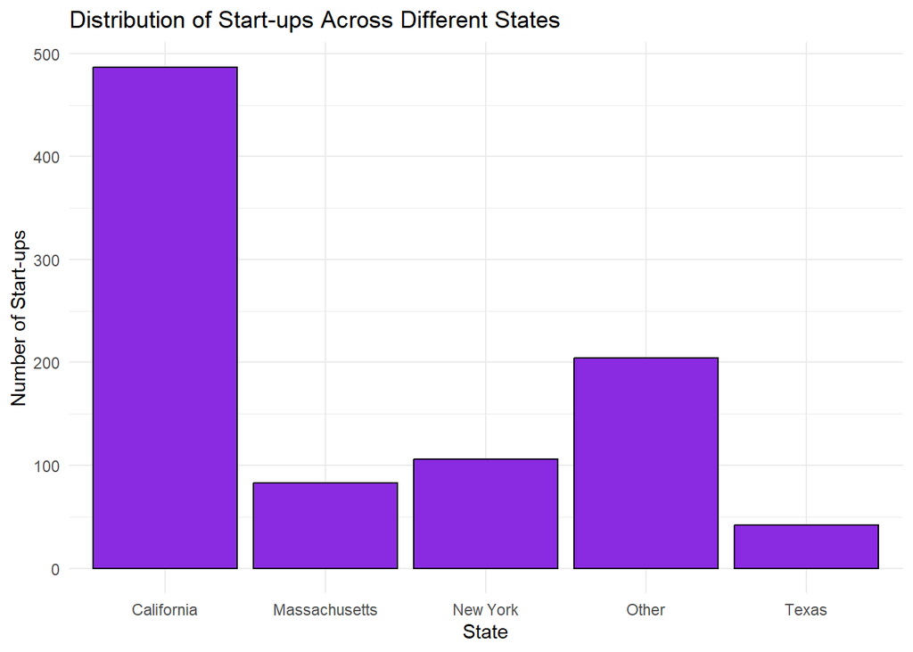

```r
state_counts <- apply(start_up[, c("is_CA", "is_NY", "is_MA", "is_TX", "is_otherstate")], 2, function(x) sum(x == 1))

# Create data frame
state_data <- data.frame(State = c("California", "New York", "Massachusetts", "Texas", "Other"), Count = state_counts)

#  Barplot
ggplot(state_data, aes(x = State, y = Count)) +
  geom_bar(stat = "identity", fill = "blueviolet", color = "black") +
  labs(title = "Distribution of Start-ups Across Different States",
       x = "State", y = "Number of Start-ups") +
  theme_minimal() +
  scale_x_discrete(labels = c("is_CA" = "California",
                              "is_NY" = "New York",
                              "is_MA" = "Massachusetts",
                              "is_TX" = "Texas",
                              "is_otherstate" = "Other"))
```

```r
state_data$Proportion <- state_data$Count / sum(state_data$Count) * 100

state_data
```

```
##                       State Count Proportion
## is_CA            California   487  52.819957
## is_NY              New York   106  11.496746
## is_MA         Massachusetts    83   9.002169
## is_TX                 Texas    42   4.555315
## is_otherstate         Other   204  22.125813
```

What is the distribution and concentration of start-ups across different categories?

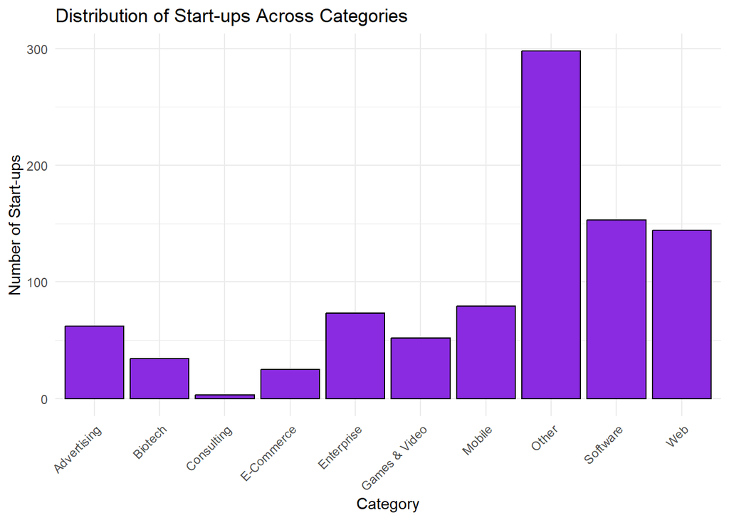

```r
# Category counts
category_counts <- apply(start_up[, c("is_software",
                              "is_web",
                              "is_mobile",
                              "is_enterprise",
                              "is_advertising",
                              "is_gamesvideo",
                              "is_ecommerce",
                              "is_biotech",
                              "is_consulting",
                              "is_othercategory")], 2, function(x) sum(x == 1))

# Create data frame
category_data <- data.frame(Category = c("Software", "Web", "Mobile", "Enterprise", "Advertising", "Games & Video", "E-Commerce", "Biotech", "Consulting", "Other"), Count = category_counts)

# Barplot
ggplot(category_data, aes(x = Category, y = Count)) +
  geom_bar(stat = "identity", fill = "blueviolet", color = "black") +
  labs(title = "Distribution of Start-ups Across Categories",
       x = "Category", y = "Number of Start-ups") +
  theme_minimal() +
  scale_x_discrete(labels = c("is_software" = "Software",
                              "is_web" = "Web",
                              "is_mobile" = "Mobile",
                              "is_enterprise" = "Enterprise",
                              "is_advertising" = "Advertising",
                              "is_gamesvideo" = "Games & Video",
                              "is_ecommerce" = "E-Commerce",
                              "is_biotech" = "Biotech",
                              "is_consulting" = "Consulting",
                              "is_othercategory" = "Other")) +
  theme(axis.text.x = element_text(angle = 45, hjust = 1))
```

```r
category_data$Proportion <- category_data$Count / sum(category_data$Count) * 100

category_data
```

```
##                       Category Count Proportion
## is_software           Software   153 16.5763814
## is_web                     Web   144 15.6013001
## is_mobile               Mobile    79  8.5590466
## is_enterprise       Enterprise    73  7.9089924
## is_advertising     Advertising    62  6.7172264
## is_gamesvideo    Games & Video    52  5.6338028
## is_ecommerce        E-Commerce    25  2.7085590
## is_biotech             Biotech    34  3.6836403
## is_consulting       Consulting     3  0.3250271
## is_othercategory         Other   298 32.2860238
```

Are there any relationships between variables?

```r
# Select numerical variables of interest
numerical_vars <- c("age_first_funding_year", "age_last_funding_year", "age_first_milestone_year",
                    "age_last_milestone_year", "funding_rounds", "funding_total_usd", "is_top500_num")

# Create an empty data frame to store correlation coefficients and p-values
correlation_results <- data.frame(Variable = character(), Correlation = numeric(), P_Value = numeric(), stringsAsFactors = FALSE)

# Calculate correlation coefficients and p-values for each numerical variable
for (var in numerical_vars) {
  # Calculate correlation coefficient
  correlation <- cor(start_up[[var]], start_up$is_acquired_num)

  # Calculate p-value
  cor_test <- cor.test(start_up$is_acquired_num, start_up[[var]])
  p_value <- cor_test$p.value

  # Store results in the data frame
  correlation_results <- rbind(correlation_results, data.frame(Variable = var, Correlation = correlation, P_Value = p_value))
}

# Print correlation coefficients and p-values
print(correlation_results)
```

```
##                   Variable Correlation      P_Value
## 1   age_first_funding_year  0.07563749 2.155525e-02
## 2    age_last_funding_year -0.07373087 2.508928e-02
## 3 age_first_milestone_year -0.25016325 1.230380e-14
## 4  age_last_milestone_year -0.35860020 2.155197e-29
## 5           funding_rounds -0.20604941 2.625508e-10
## 6        funding_total_usd -0.04017573 2.226872e-01
## 7            is_top500_num  0.31065180 4.236727e-22
```

Which industries have the highest and lowest success rates?

```r
# Name columns
industry_columns <- c("is_software" = "Software",
                      "is_web" = "Web",
                      "is_mobile" = "Mobile",
                      "is_enterprise" = "Enterprise",
                      "is_advertising" = "Advertising",
                      "is_gamesvideo" = "Games & Video",
                      "is_ecommerce" = "E-Commerce",
                      "is_biotech" = "Biotech",
                      "is_consulting" = "Consulting",
                      "is_othercategory" = "Other")

# Initialize vectors
success_rates <- numeric(length(industry_columns))
industry_names <- character(length(industry_columns))

# Calculate success rates for each industry (loop)
for (i in seq_along(industry_columns)) {
  industry_name <- names(industry_columns)[i]
  industry_label <- industry_columns[industry_name]

  # Filter successful startups for the current industry
  successful_startups <- subset(start_up, start_up$is_acquired_num == 1 & start_up[[industry_name]] == 1)

  # Calculate success rate for the current industry
  success_rate <- nrow(successful_startups) / sum(start_up[[industry_name]] == 1)  # Divide count of successful startups by total startups in the industry

  # Store success rate and industry names
  success_rates[i] <- success_rate
  industry_names[i] <- industry_label
}

# Combine industry names and success rates into a data frame
industry_success_rates <- data.frame(Industry = industry_names, Success_Rate = success_rates)

# Find the highest success rate
highest_success_rate <- industry_success_rates[which.max(industry_success_rates$Success_Rate), ]

# If the highest success rate is "Other", find the second-highest
if (highest_success_rate$Industry == "Other") {
  highest_success_rate <- industry_success_rates[order(-industry_success_rates$Success_Rate), ][2, ]
}

# Find the lowest success rate
lowest_success_rate <- industry_success_rates[which.min(industry_success_rates$Success_Rate), ]

# Display the highest success rate
print(paste("Industry with the highest success rate:", highest_success_rate$Industry, "(", round(highest_success_rate$Success_Rate * 100, 2), "%)"))
```

```
## [1] "Industry with the highest success rate: E-Commerce ( 56 %)"
```

```r
# Display the lowest success rate
print(paste("Industry with the lowest success rate:", lowest_success_rate$Industry, "(", round(lowest_success_rate$Success_Rate * 100, 2), "%)"))
```

```
## [1] "Industry with the lowest success rate: Enterprise ( 23.29 %)"
```

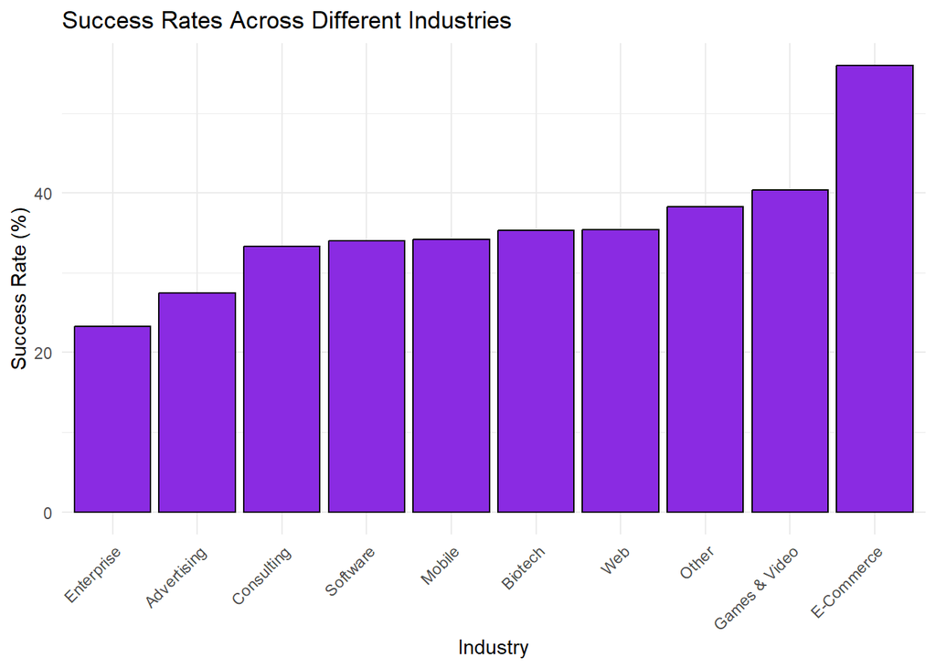

```r
# Barplot
ggplot(industry_success_rates, aes(x = reorder(Industry, Success_Rate), y = Success_Rate * 100)) +
  geom_bar(stat = "identity", fill = "blueviolet", color = "black") +
  labs(title = "Success Rates Across Different Industries",
       x = "Industry", y = "Success Rate (%)") +
  theme_minimal() +
  theme(axis.text.x = element_text(angle = 45, hjust = 1))
```

What proportion of start-ups have been acquired versus closed?

```r
# Filter acquired startups
acquired_count <- sum(start_up$status == "acquired")

# Filter closed startups
closed_count <- sum(start_up$status == "closed")

# Calculate proportions
total_startups <- nrow(start_up)
acquired_proportion <- acquired_count / total_startups * 100
closed_proportion <- closed_count / total_startups * 100

# Round to 2 decimal places
acquired_proportion <- round(acquired_proportion, 2)
closed_proportion <- round(closed_proportion, 2)

print(paste("Proportion of startups that are acquired:", acquired_proportion, "%"))
```

```
## [1] "Proportion of startups that are acquired: 64.68 %"
```

```r
print(paste("Proportion of startups that are closed:", closed_proportion, "%"))
```

```
## [1] "Proportion of startups that are closed: 35.32 %"
```

What are the counts of acquired and closed start-up companies for each state?

```r
# Calculate counts
acquired_startups <- start_up[start_up$is_acquired == 1, ]
closed_startups <- start_up[start_up$is_closed == 1, ]

# Table
acquired_state_counts <- table(acquired_startups$state_code)
closed_state_counts <- table(closed_startups$state_code)

# Create data frames
acquired_state_data <- data.frame(State1 = names(acquired_state_counts), 'Acquired Count' = acquired_state_counts)
closed_state_data <- data.frame(State2 = names(closed_state_counts), 'Closed Count' = closed_state_counts)

# Merge data frames
combined_state_data <- merge(acquired_state_data, closed_state_data, by.x = "State1", by.y = "State2", all = TRUE)

# Name columns
colnames(combined_state_data)[colnames(combined_state_data) == "Acquired Count.x"] <- "Acquired Count"
colnames(combined_state_data)[colnames(combined_state_data) == "Closed Count.y"] <- "Closed Count"

print(subset(combined_state_data, select = -c(Acquired.Count.Var1, Closed.Count.Var1)))
```

```
##    State1 Acquired.Count.Freq Closed.Count.Freq
## 1      AR                  NA                 1
## 2      AZ                   1                 1
## 3      CA                 332               156
## 4      CO                  14                 5
## 5      CT                  NA                 4
## 6      DC                   2                 2
## 7      FL                   2                 4
## 8      GA                   6                 5
## 9      ID                  NA                 1
## 10     IL                   9                 9
## 11     IN                   1                 1
## 12     KY                   1                 1
## 13     MA                  64                19
## 14     MD                   5                 2
```

[output cut: 21 more lines]

Are there significant differences in the acquisition rates of start-ups across different states?

> The output of Fisher’s exact test provides information about the statistical significance of the relationship between the two variables in the contingency table.

```r
# Contingency table
contingency_table <- table(combined_state_data$State1, combined_state_data$`Acquired.Count.Freq`)

# Fisher's exact test
fisher_test <- fisher.test(contingency_table)

print(fisher_test)
```

```
##
##  Fisher's Exact Test for Count Data
##
## data:  contingency_table
## p-value = 1
## alternative hypothesis: two.sided
```

> A p-value of 1 indicates that there is no evidence to reject the null hypothesis, suggesting that there is no significant association between the acquisition rates of start-ups and the states they are located in. Therefore, based on this test, there are no significant differences in the acquisition rates across different states.

## Statistical Analysis

```r
# Calculate mean funding rounds for acquired start-ups
mean_funding_rounds_acquired <- round(mean(start_up$funding_rounds[start_up$is_acquired == 1], na.rm = TRUE), 2)

# Calculate mean funding rounds for closed start-ups
mean_funding_rounds_closed <- round(mean(start_up$funding_rounds[start_up$is_closed == 1], na.rm = TRUE), 2)

cat("Mean funding rounds for acquired start-ups: ", mean_funding_rounds_acquired, "\n")
```

```
## Mean funding rounds for acquired start-ups:  2.52
```

```r
cat("Mean funding rounds for closed start-ups: ", mean_funding_rounds_closed, "\n")
```

```
## Mean funding rounds for closed start-ups:  1.92
```

> Acquired startups tend to have more funding rounds.

```r
# Define the variables
sign_vars <- c("age_first_funding_year", "age_last_funding_year",
               "age_first_milestone_year", "age_last_milestone_year",
               "funding_rounds")

startup_colors <- c("closed" = "deeppink", "acquired" = "blueviolet")
```

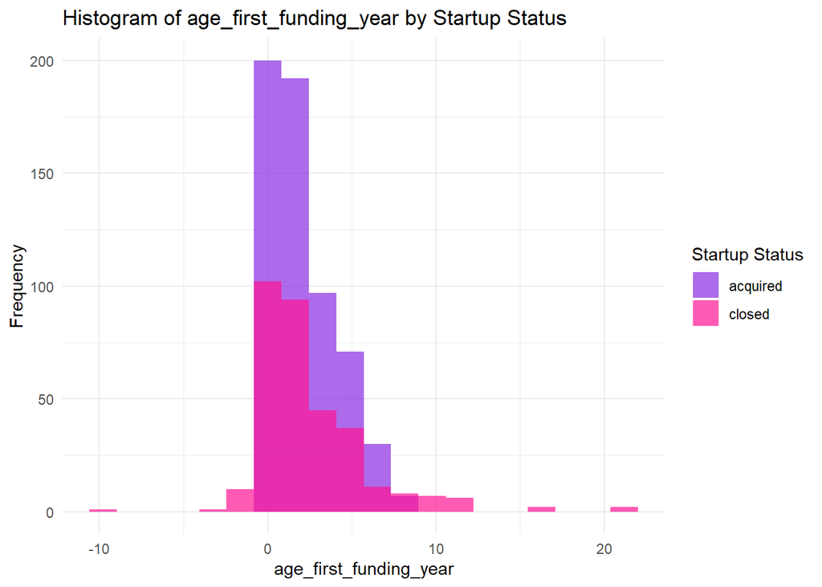

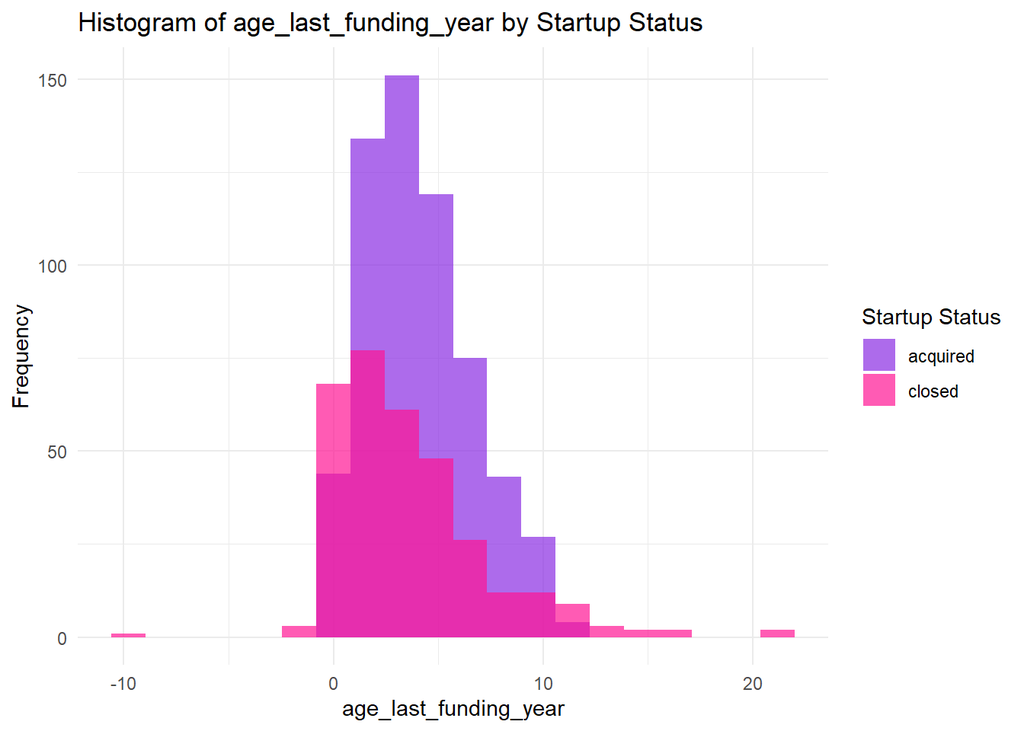

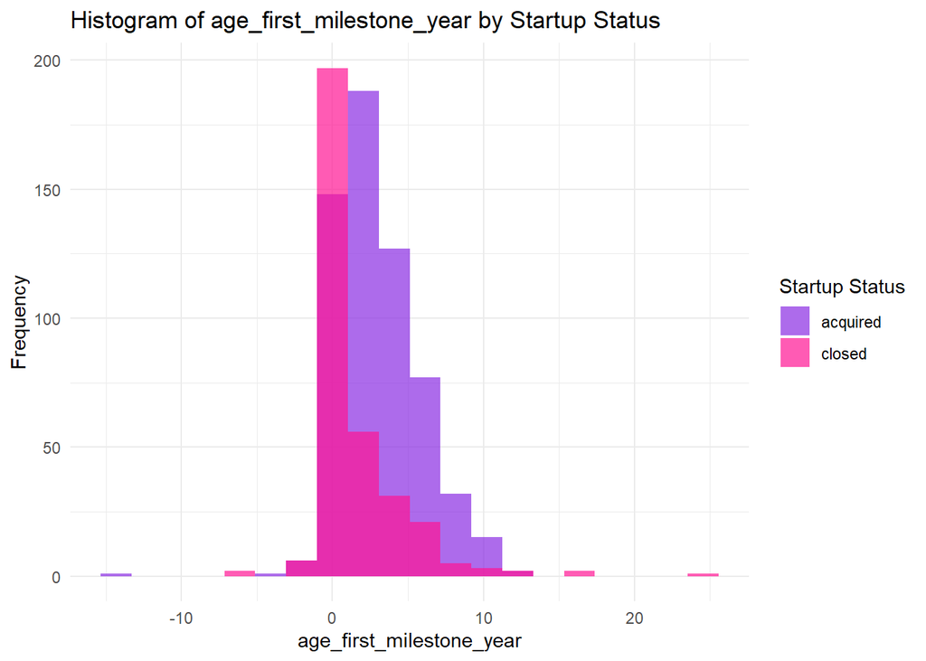

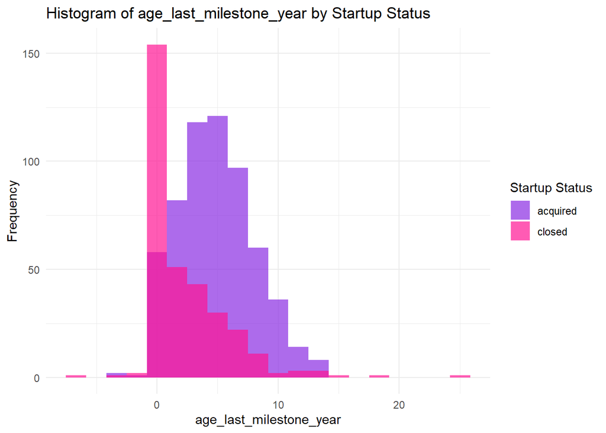

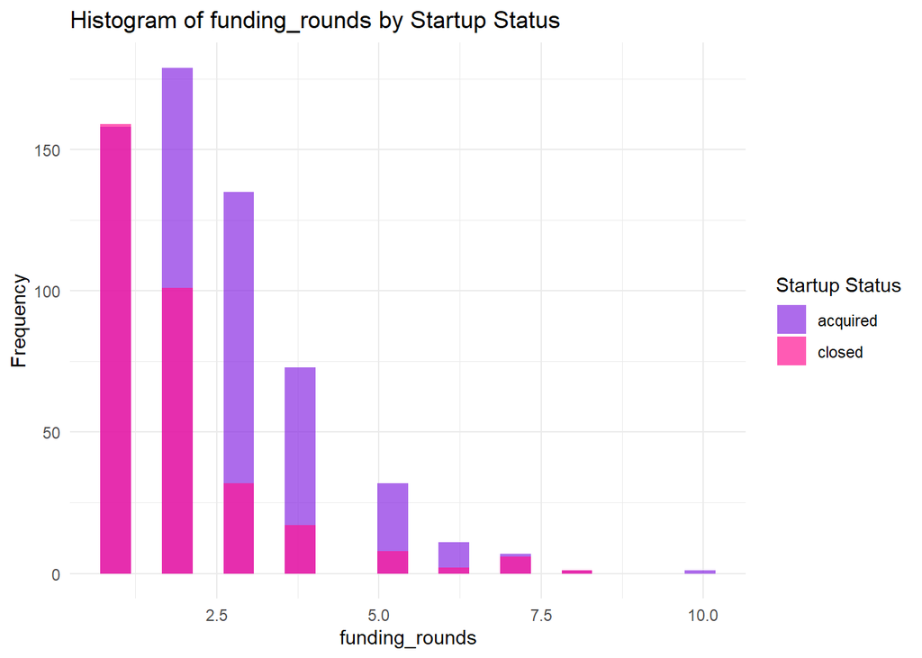

```r
# Histograms
histogram_plots <- lapply(sign_vars, function(var) {
  ggplot(start_up, aes(x = !!sym(var), fill = status)) +
    geom_histogram(position = "identity", alpha = 0.7, bins = 20) +
    labs(title = paste("Histogram of", var, "by Startup Status"),
         x = var,
         y = "Frequency",
         fill = "Startup Status") +
    scale_fill_manual(values = startup_colors) +
    theme_minimal()
})

# Print histograms
print(histogram_plots)
```

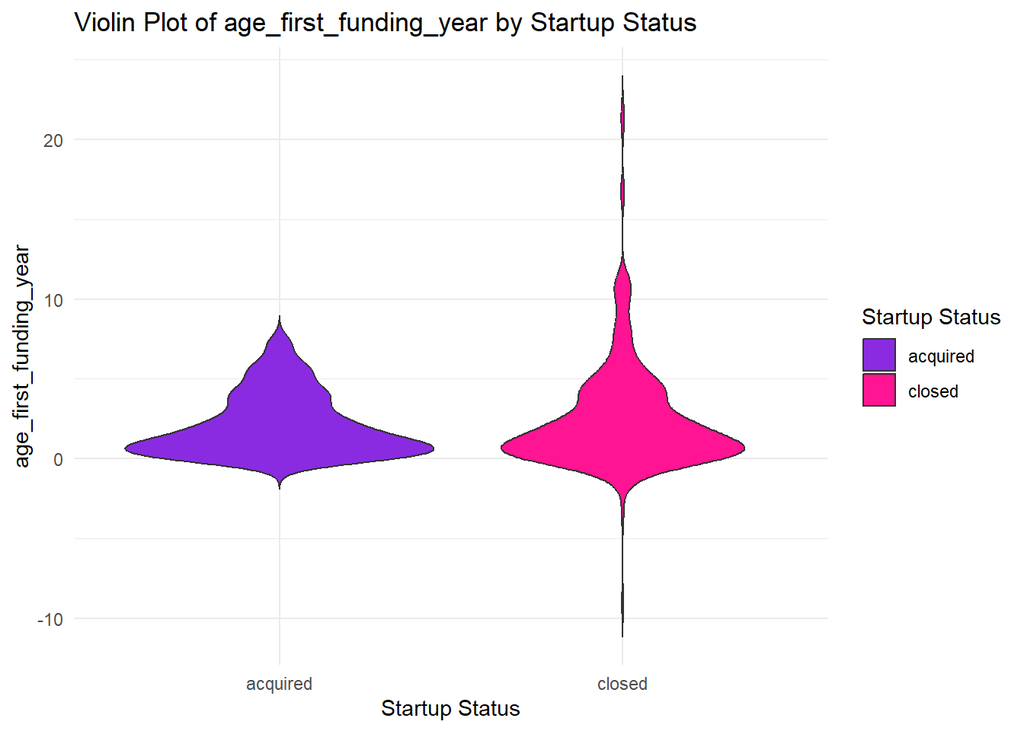

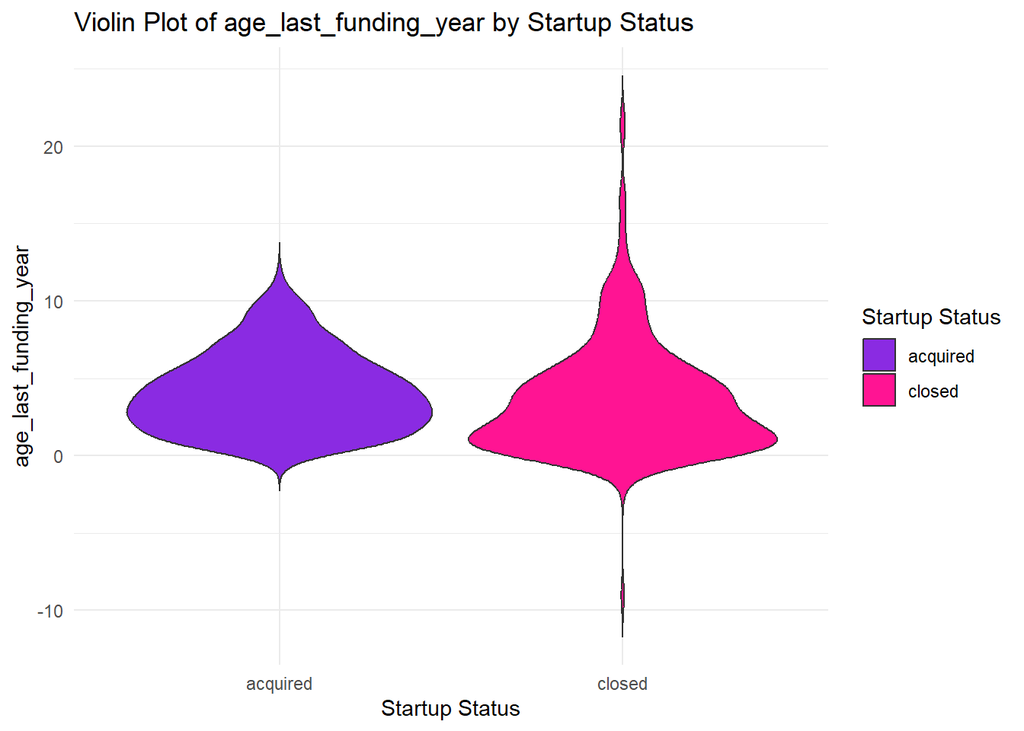

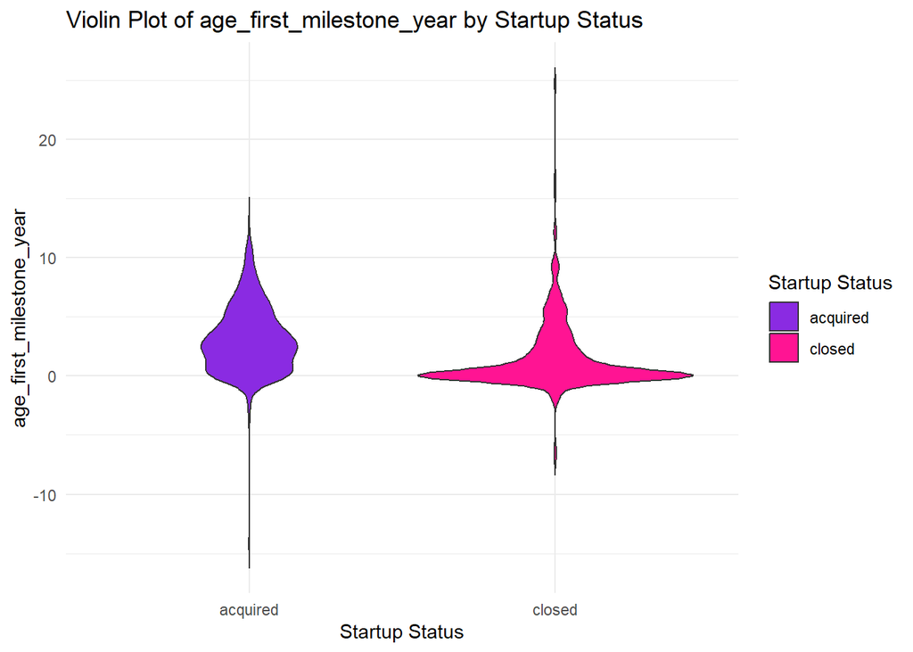

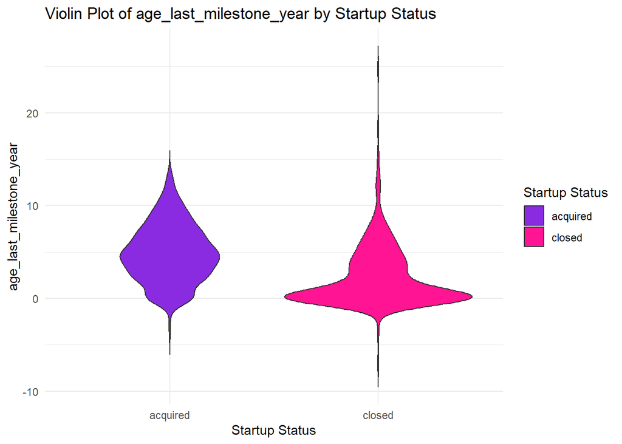

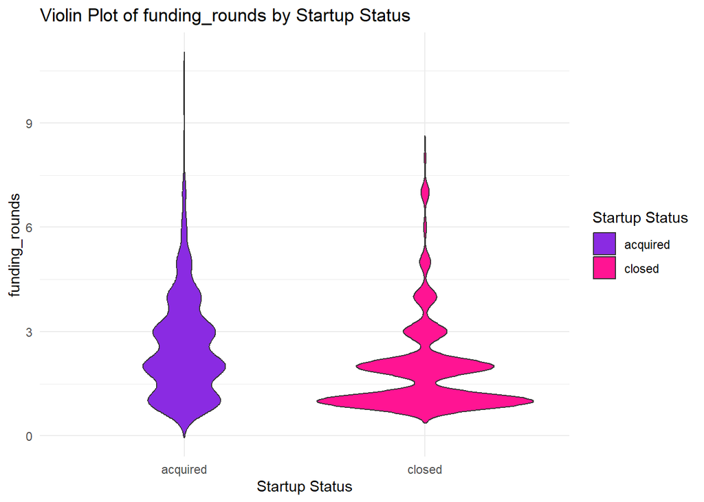

```r
# Violin Plots
violin_plots <- lapply(sign_vars, function(var) {
  ggplot(start_up, aes(x = status, y = !!sym(var), fill = status)) +
    geom_violin(trim = FALSE) +
    labs(title = paste("Violin Plot of", var, "by Startup Status"),
         x = "Startup Status",
         y = var,
         fill = "Startup Status") +
    scale_fill_manual(values = startup_colors) +
    theme_minimal()
})
print(violin_plots)
```

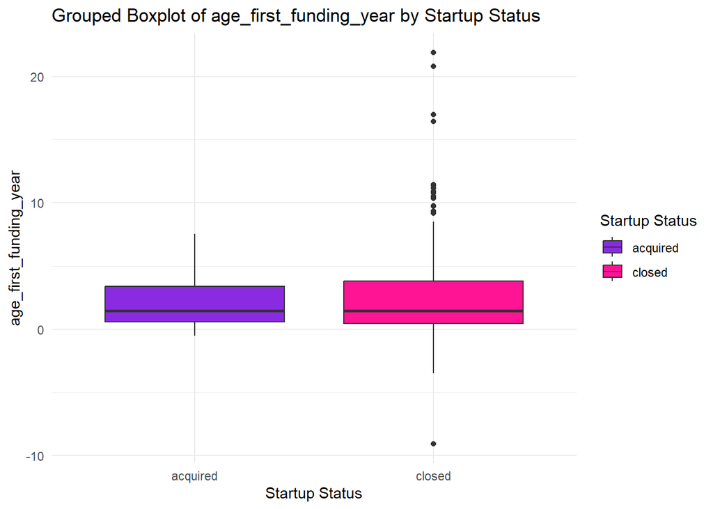

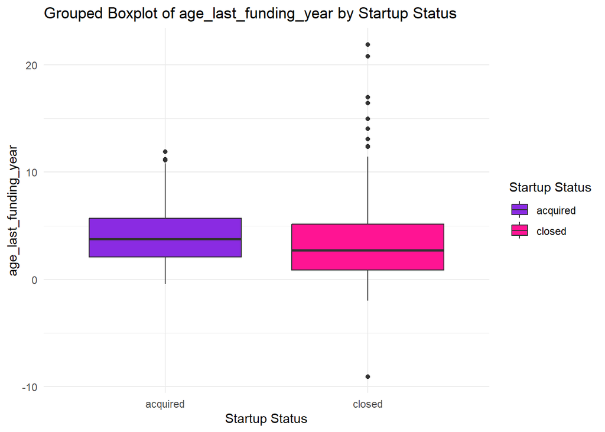

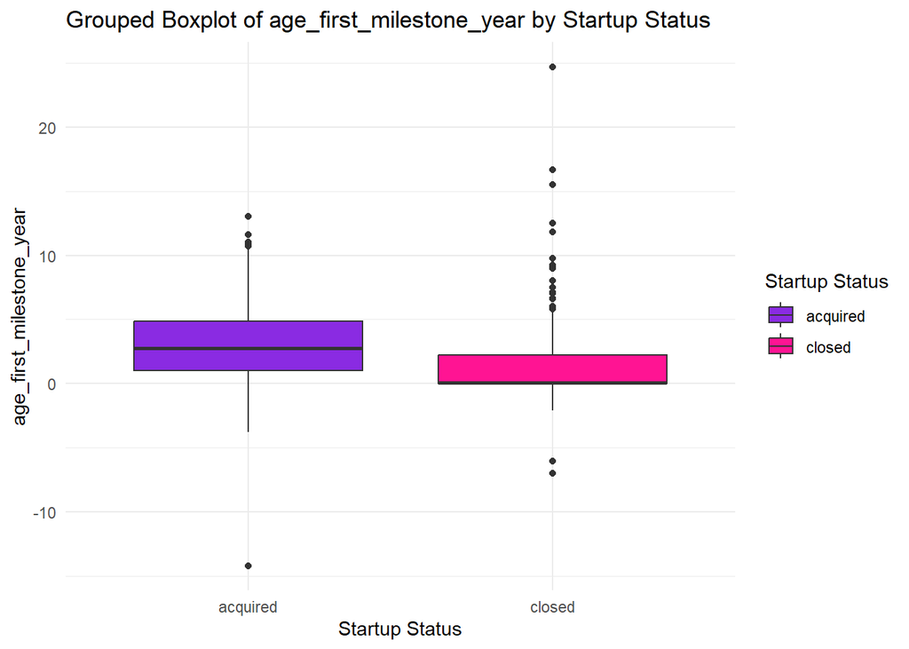

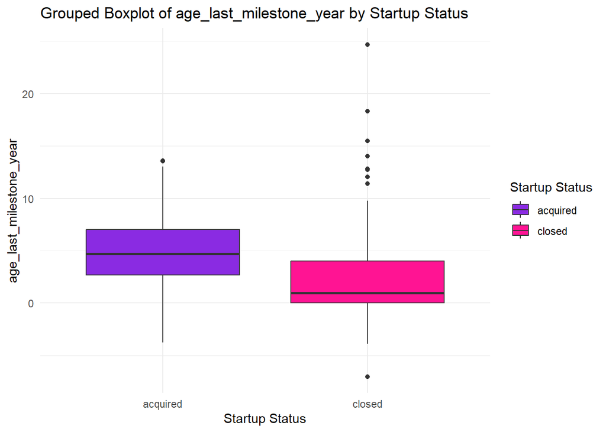

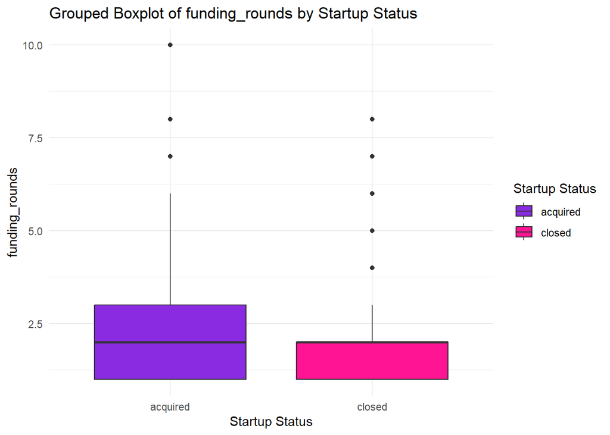

```r
# Grouped boxplots
boxplot_plots <- lapply(sign_vars, function(var) {
  ggplot(start_up, aes(x = status, y = !!sym(var), fill = status)) +
    geom_boxplot() +
    labs(title = paste("Grouped Boxplot of", var, "by Startup Status"),
         x = "Startup Status",
         y = var,
         fill = "Startup Status") +
    scale_fill_manual(values = startup_colors) +
    theme_minimal()
})

# Print the plots
print(boxplot_plots)
```

## Predictive Modeling

```r
# Simple partition into train (80%) and test (20%) set
set.seed(687) # Do NOT change this
trainIndex <- createDataPartition(start_up$is_acquired, p = .8,
                                  list = FALSE,
                                  times = 1)

start_up_train <- start_up[trainIndex, ]
start_up_test <- start_up[-trainIndex, ]

# rm(trainIndex) Remove this when you no longer need it!
```

```r
table(start_up_train$is_acquired)
```

```
##
##   0   1
## 261 478
```

```r
start_up_train$is_acquired %>%
  table() %>%
  prop.table() * 100
```

```
## .
##      0      1
## 35.318 64.682
```

> There are 261 instances where the startup is not acquired (0). There are 478 instances where the startup is acquired (1).

> Approximately 35.32% of startups in the training set are not acquired. Approximately 64.68% of startups in the training set are acquired.

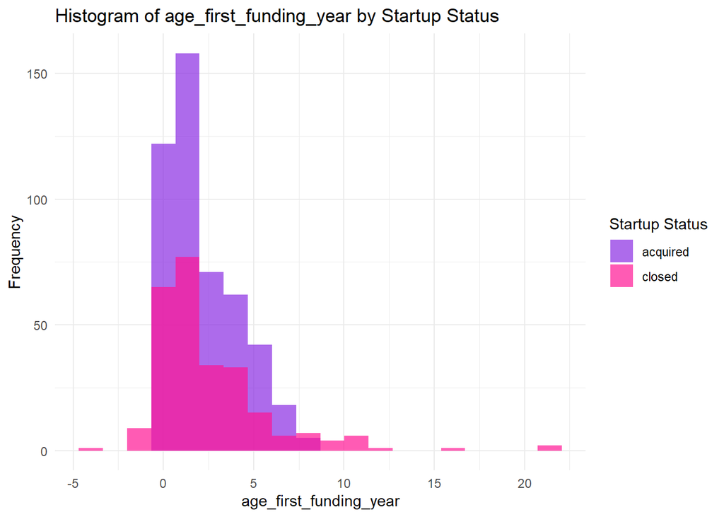

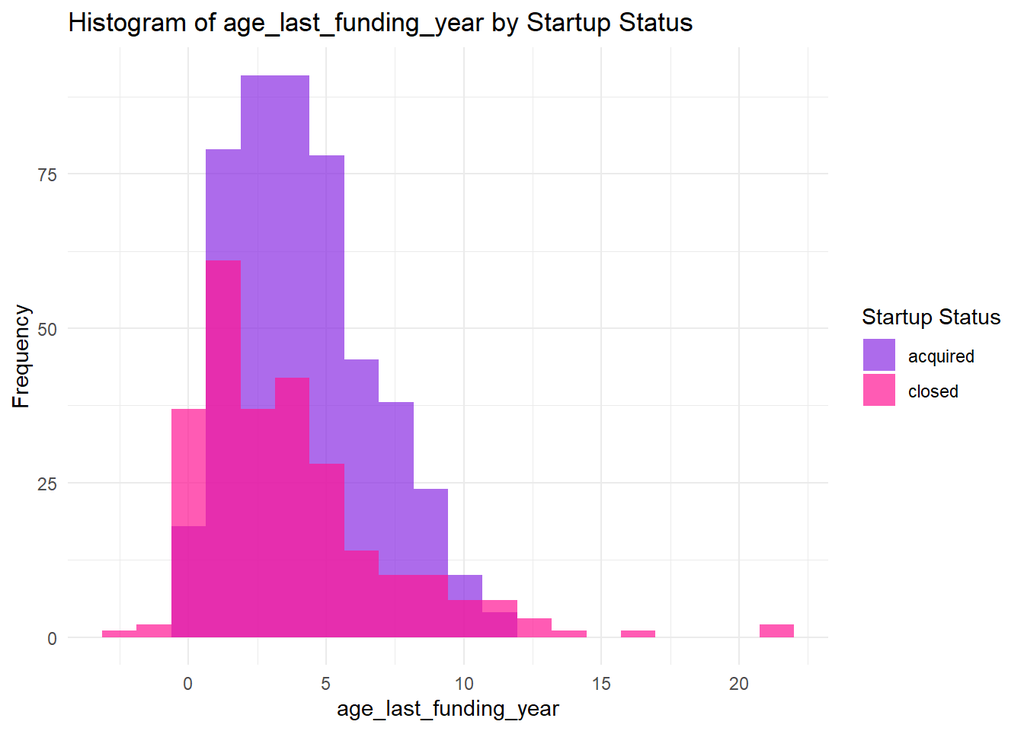

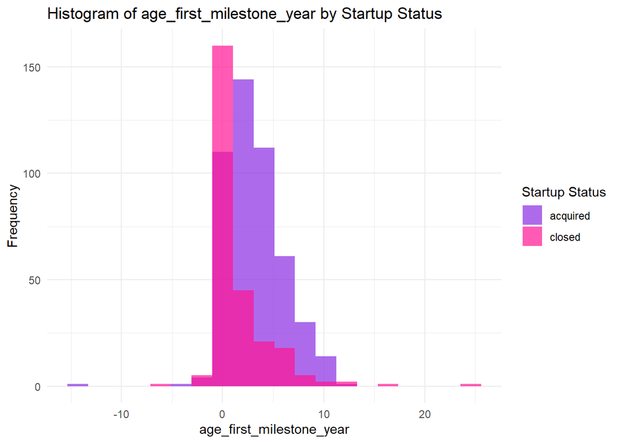

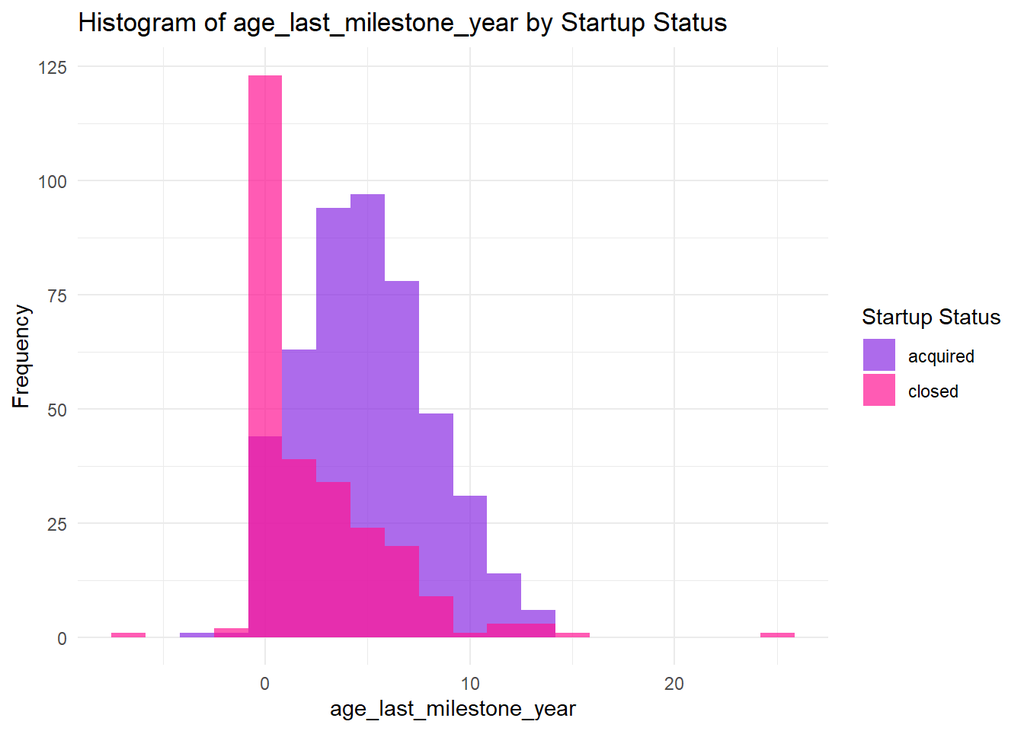

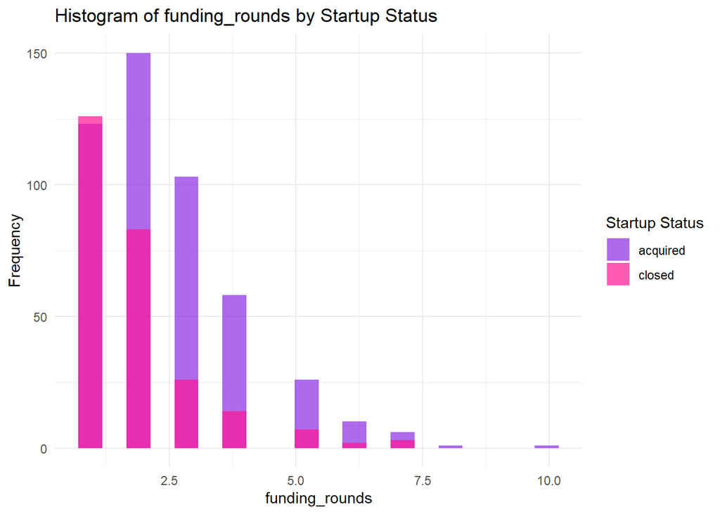

```r
# Histograms
histogram_plots_train <- lapply(sign_vars, function(var) {
  ggplot(start_up_train, aes(x = !!sym(var), fill = status)) +
    geom_histogram(position = "identity", alpha = 0.7, bins = 20) +
    labs(title = paste("Histogram of", var, "by Startup Status"),
         x = var,
         y = "Frequency",
         fill = "Startup Status") +
    scale_fill_manual(values = startup_colors) +
    theme_minimal()
})

print(histogram_plots_train)
```

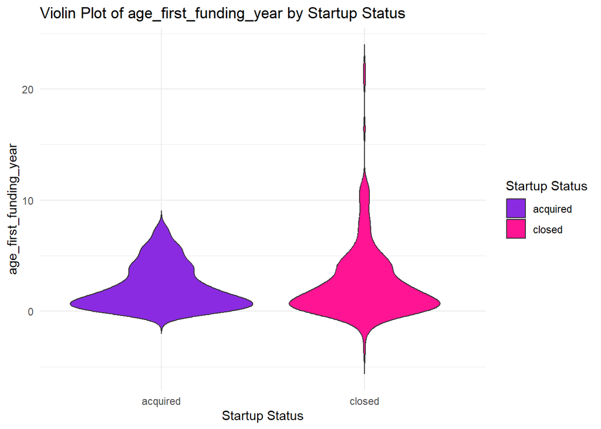

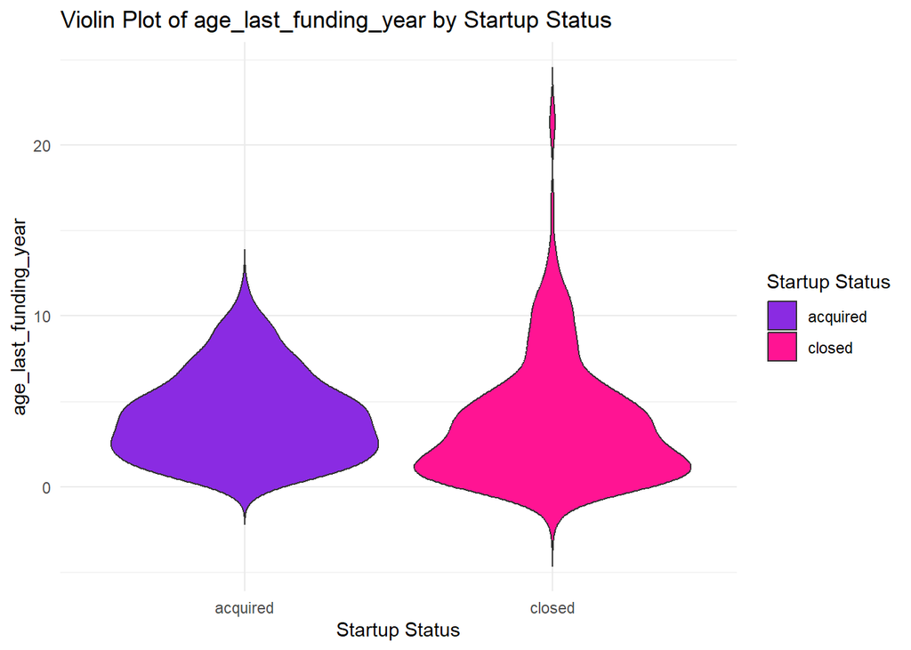

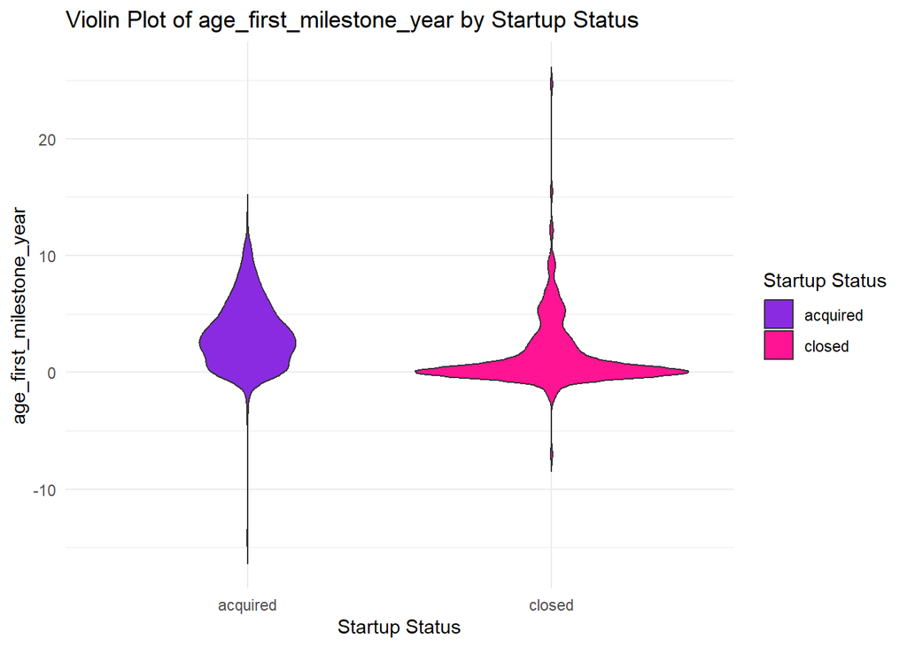

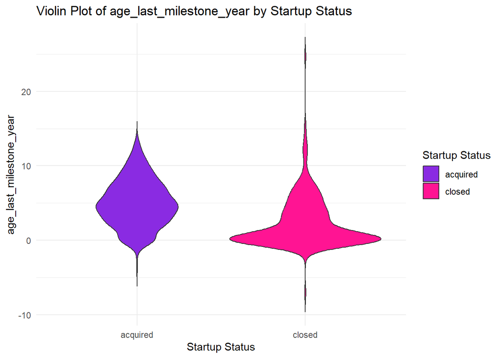

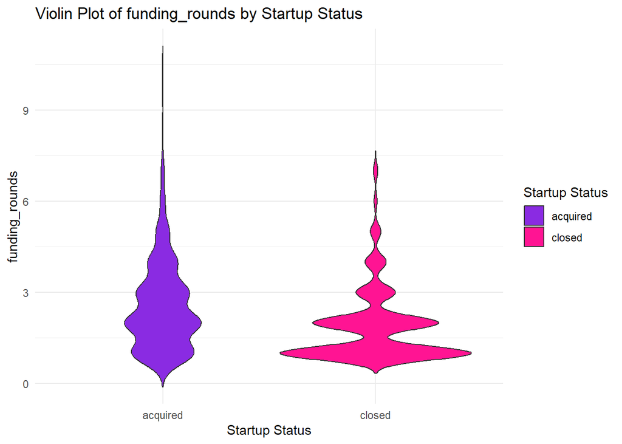

```r
# Violin Plots
violin_plots_train <- lapply(sign_vars, function(var) {
  ggplot(start_up_train, aes(x = status, y = !!sym(var), fill = status)) +
    geom_violin(trim = FALSE) +
    labs(title = paste("Violin Plot of", var, "by Startup Status"),
         x = "Startup Status",
         y = var,
         fill = "Startup Status") +
    scale_fill_manual(values = startup_colors) +
    theme_minimal()
})

print(violin_plots_train)
```

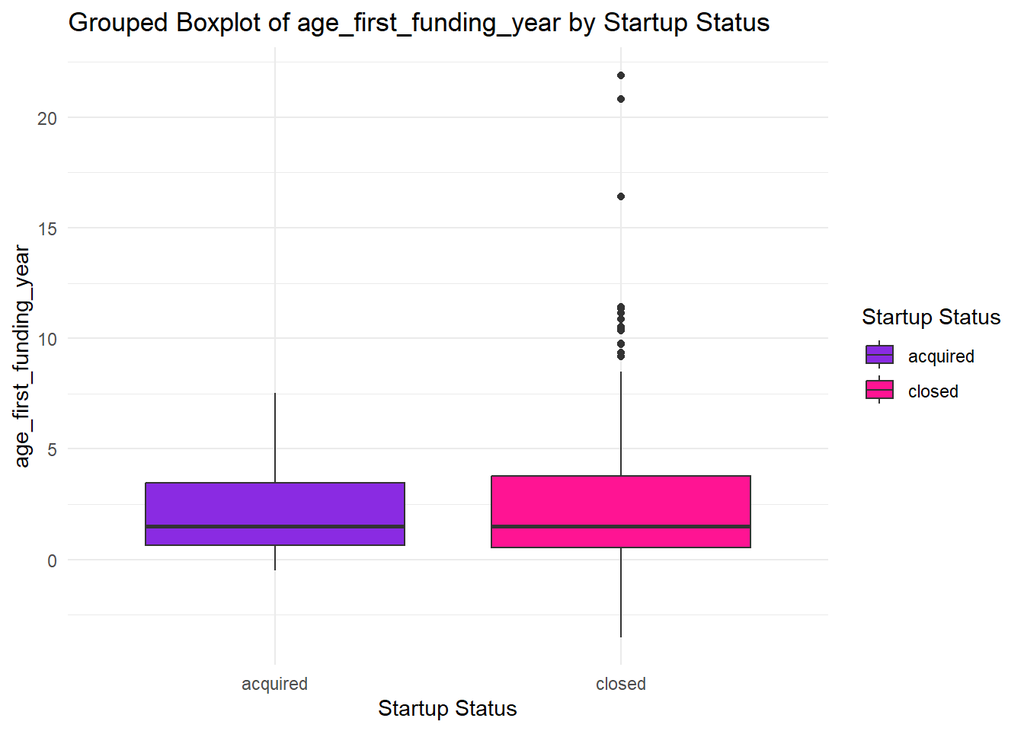

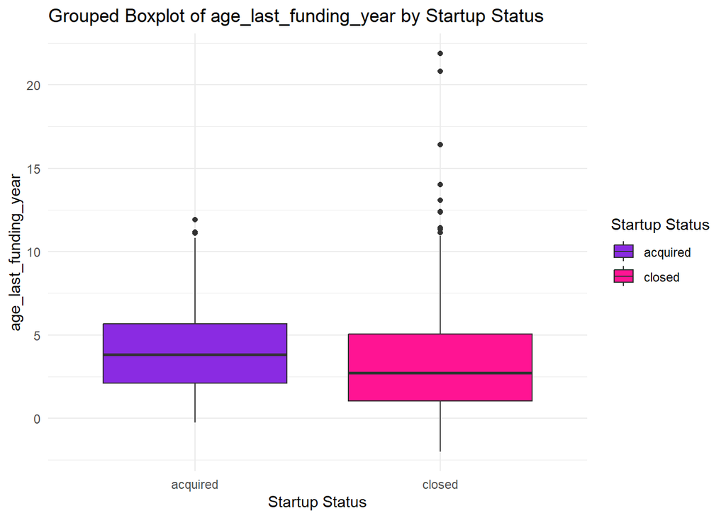

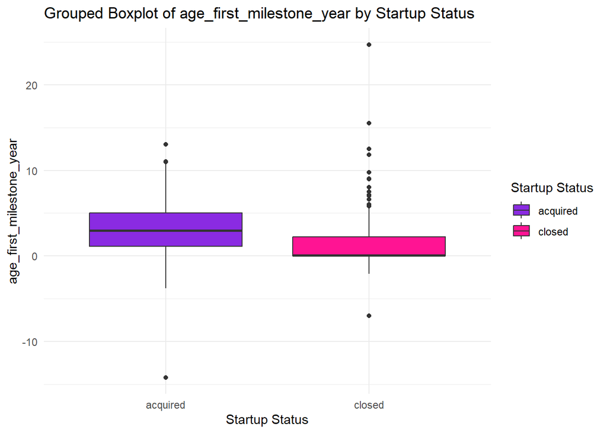

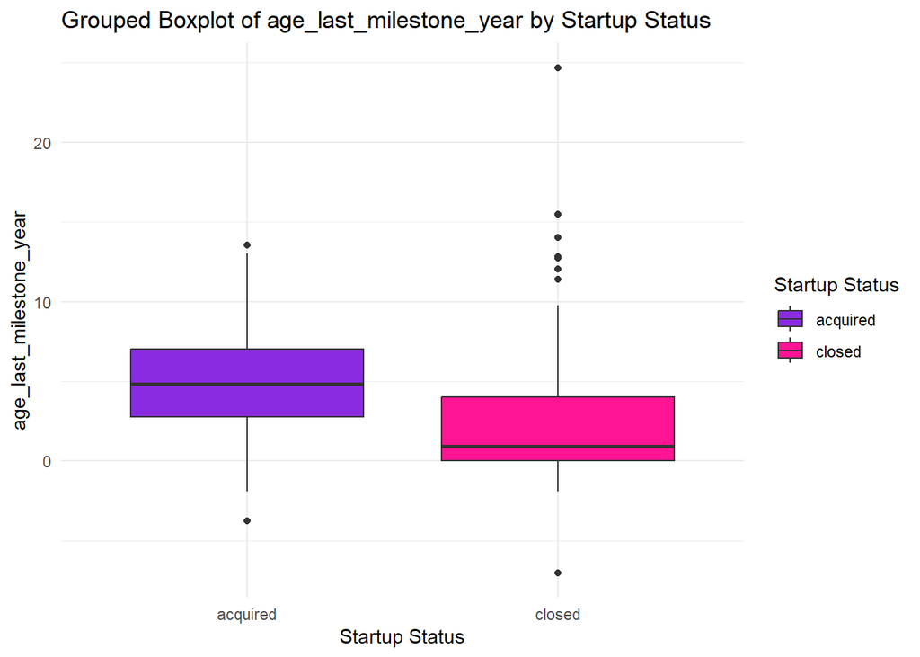

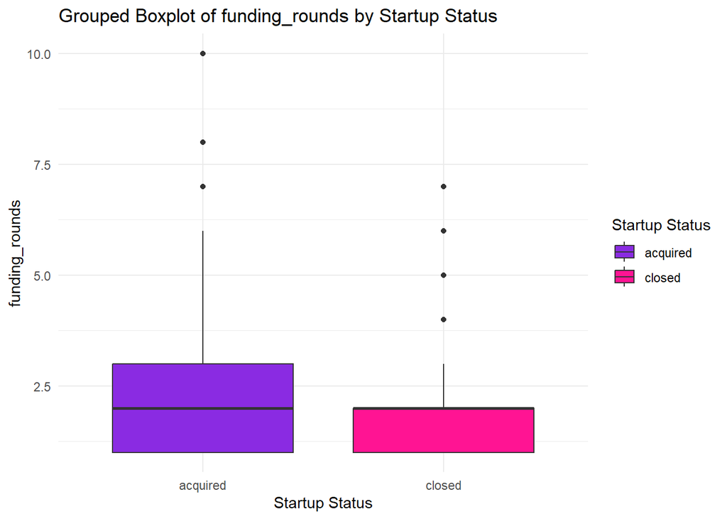

```r
# Grouped boxplots
boxplot_plots_train <- lapply(sign_vars, function(var) {
  ggplot(start_up_train, aes(x = status, y = !!sym(var), fill = status)) +
    geom_boxplot() +
    labs(title = paste("Grouped Boxplot of", var, "by Startup Status"),
         x = "Startup Status",
         y = var,
         fill = "Startup Status") +
    scale_fill_manual(values = startup_colors) +
    theme_minimal()
})

print(boxplot_plots_train)
```

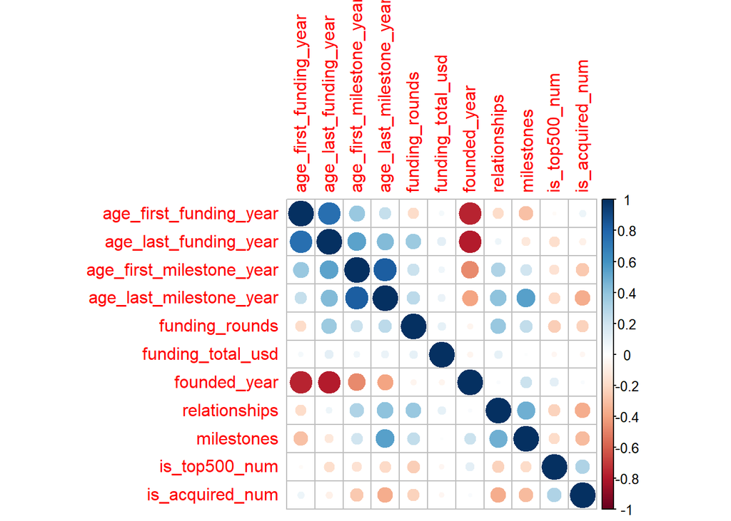

```r
# Calculate correlation matrix
corrmat <- cor(start_up_train[, c("age_first_funding_year", "age_last_funding_year", "age_first_milestone_year",
                                   "age_last_milestone_year", "funding_rounds", "funding_total_usd",
                                   "founded_year", "relationships", "milestones", "is_top500_num",
                                   "is_acquired_num")])

# Create correlation plot
corrplot::corrplot(corrmat)
```

```r
# Print correlation values
cor(start_up_train[, c("age_first_funding_year", "age_last_funding_year", "age_first_milestone_year",
                       "age_last_milestone_year", "funding_rounds", "funding_total_usd",
                       "is_top500_num", "founded_year", "relationships", "milestones",
                       "is_acquired_num")])
```

```
##                          age_first_funding_year age_last_funding_year
## age_first_funding_year               1.00000000            0.75917809
## age_last_funding_year                0.75917809            1.00000000
## age_first_milestone_year             0.37469263            0.53399610
## age_last_milestone_year              0.23158579            0.43418970
## funding_rounds                      -0.18386899            0.36417096
## funding_total_usd                    0.04342588            0.11311885
## is_top500_num                       -0.02497636           -0.17001377
## founded_year                        -0.76793305           -0.78876411
## relationships                       -0.18406411            0.07108173
## milestones                          -0.29960865           -0.12412147
## is_acquired_num                      0.07455621           -0.07561550
##                          age_first_milestone_year age_last_milestone_year
## age_first_funding_year                 0.37469263              0.23158579
## age_last_funding_year                  0.53399610              0.43418970
## age_first_milestone_year               1.00000000              0.82422685
## age_last_milestone_year                0.82422685              1.00000000
## funding_rounds                         0.21418763              0.26158852
## funding_total_usd                      0.06296437              0.08998258
## is_top500_num                         -0.15283406             -0.19756820
## founded_year                          -0.47367198             -0.39771755
## relationships                          0.30188042              0.40280061
## milestones                             0.19951673              0.54126169
## is_acquired_num                       -0.26576943             -0.36631621
##                          funding_rounds funding_total_usd is_top500_num
## age_first_funding_year      -0.18386899        0.04342588   -0.02497636
## age_last_funding_year        0.36417096        0.11311885   -0.17001377
## age_first_milestone_year     0.21418763        0.06296437   -0.15283406
## age_last_milestone_year      0.26158852        0.08998258   -0.19756820
## funding_rounds               1.00000000        0.10967649   -0.24856693
## funding_total_usd            0.10967649        1.00000000   -0.04445533
## is_top500_num               -0.24856693       -0.04445533    1.00000000
## founded_year                -0.05771575       -0.05514207    0.11380959
## relationships                0.37057684        0.10046257   -0.22691747
## milestones                   0.24526445        0.01267366   -0.18746805
## is_acquired_num             -0.22401128       -0.04843500    0.30622745
##                          founded_year relationships  milestones is_acquired_num
## age_first_funding_year    -0.76793305   -0.18406411 -0.29960865      0.07455621
## age_last_funding_year     -0.78876411    0.07108173 -0.12412147     -0.07561550
## age_first_milestone_year  -0.47367198    0.30188042  0.19951673     -0.26576943
## age_last_milestone_year   -0.39771755    0.40280061  0.54126169     -0.36631621
## funding_rounds            -0.05771575    0.37057684  0.24526445     -0.22401128
## funding_total_usd         -0.05514207    0.10046257  0.01267366     -0.04843500
## is_top500_num              0.11380959   -0.22691747 -0.18746805      0.30622745
## founded_year               1.00000000    0.02380059  0.21170762      0.02410970
## relationships              0.02380059    1.00000000  0.48965036     -0.36031149
## milestones                 0.21170762    0.48965036  1.00000000     -0.31965440
## is_acquired_num            0.02410970   -0.36031149 -0.31965440      1.00000000
```

> There is a strong positive corroleation between age_first_funding_year and age_last_funding_year, and a strong positive correlation between age_first_milestone_year and age_last_milestone_year. When dealing with dates, for example, if a startup recieved their first funding earlier, they likely recieved their last funding earlier also. Same goes for milestones.

```r
# Define the columns you want to include in the model
selected_columns <- c("relationships", "milestones", "is_software", "is_web", "is_mobile",
                      "is_enterprise", "is_advertising", "is_gamesvideo", "is_ecommerce",
                      "is_biotech", "is_consulting", "is_othercategory", "avg_participants",
                      "is_top500", "is_acquired")

# Create a new training dataset with selected columns
start_up_train_selected <- start_up_train[, selected_columns]

# Create a new testing dataset with selected columns
start_up_test_selected <- start_up_test[, selected_columns]
```

Can we predict if a start-up will be successful (get acquired)?

```r
# Create a vector of 0's for is_acquired variable
model_train_null <- rep(0, nrow(start_up_train_selected))
model_test_null <- rep(0, nrow(start_up_test_selected))

# Confusion matrix for training data
cm_train_null <- caret::confusionMatrix(as.factor(model_train_null), start_up_train_selected$is_acquired, positive = "1")
cm_train_null
```

```
## Confusion Matrix and Statistics
##
##           Reference
## Prediction   0   1
##          0 261 478
##          1   0   0
##
##                Accuracy : 0.3532
##                  95% CI : (0.3187, 0.3888)
##     No Information Rate : 0.6468
##     P-Value [Acc > NIR] : 1
##
##                   Kappa : 0
##
##  Mcnemar's Test P-Value : <2e-16
##
##             Sensitivity : 0.0000
##             Specificity : 1.0000
##          Pos Pred Value :    NaN
##          Neg Pred Value : 0.3532
##              Prevalence : 0.6468
##          Detection Rate : 0.0000
##    Detection Prevalence : 0.0000
##       Balanced Accuracy : 0.5000
##
##        'Positive' Class : 1
##
```

```r
# Confusion matrix for test data
cm_test_null <- caret::confusionMatrix(as.factor(model_test_null), start_up_test_selected$is_acquired, positive = "1")
cm_test_null
```

```
## Confusion Matrix and Statistics
##
##           Reference
## Prediction   0   1
##          0  65 119
##          1   0   0
##
##                Accuracy : 0.3533
##                  95% CI : (0.2844, 0.427)
##     No Information Rate : 0.6467
##     P-Value [Acc > NIR] : 1
##
##                   Kappa : 0
##
##  Mcnemar's Test P-Value : <2e-16
##
##             Sensitivity : 0.0000
##             Specificity : 1.0000
##          Pos Pred Value :    NaN
##          Neg Pred Value : 0.3533
##              Prevalence : 0.6467
##          Detection Rate : 0.0000
##    Detection Prevalence : 0.0000
##       Balanced Accuracy : 0.5000
##
##        'Positive' Class : 1
##
```

```r
# Train the logistic regression model with selected variables
model_lr <- glm(is_acquired ~ . - is_acquired,
                data = start_up_train_selected, family = binomial(link = "logit"), maxit = 1000)

# Convert fitted model values to fitted classes. Use 0.5 as the threshold for classifying a case as a 1.
class_train_lr <- as.factor(ifelse(predict(model_lr, type = "response") > 0.5, 1, 0))

# Confusion matrix for training set
cm_train_lr <- confusionMatrix(class_train_lr, start_up_train_selected$is_acquired, positive = "1")

cm_train_lr
```

```
## Confusion Matrix and Statistics
##
##           Reference
## Prediction   0   1
##          0 145  57
##          1 116 421
##
##                Accuracy : 0.7659
##                  95% CI : (0.7337, 0.796)
##     No Information Rate : 0.6468
##     P-Value [Acc > NIR] : 1.774e-12
##
##                   Kappa : 0.4599
##
##  Mcnemar's Test P-Value : 1.035e-05
##
##             Sensitivity : 0.8808
##             Specificity : 0.5556
##          Pos Pred Value : 0.7840
##          Neg Pred Value : 0.7178
##              Prevalence : 0.6468
##          Detection Rate : 0.5697
##    Detection Prevalence : 0.7267
##       Balanced Accuracy : 0.7182
##
##        'Positive' Class : 1
##
```

```r
pred_lr <- predict(model_lr, newdata = start_up_test_selected, type = "response")

class_test_lr <- as.factor(ifelse(pred_lr > 0.5, 1, 0))

cm_test_lr <- confusionMatrix(class_test_lr, start_up_test_selected$is_acquired, positive = "1")
cm_test_lr
```

```
## Confusion Matrix and Statistics
##
##           Reference
## Prediction  0  1
##          0 37 22
##          1 28 97
##
##                Accuracy : 0.7283
##                  95% CI : (0.6579, 0.7911)
##     No Information Rate : 0.6467
##     P-Value [Acc > NIR] : 0.01152
##
##                   Kappa : 0.3926
##
##  Mcnemar's Test P-Value : 0.47950
##
##             Sensitivity : 0.8151
##             Specificity : 0.5692
##          Pos Pred Value : 0.7760
##          Neg Pred Value : 0.6271
##              Prevalence : 0.6467
##          Detection Rate : 0.5272
##    Detection Prevalence : 0.6793
##       Balanced Accuracy : 0.6922
##
##        'Positive' Class : 1
##
```

```r
# Train the decision tree model
model_tree1 <- train(is_acquired ~ .,
                     data = start_up_train_selected,
                     method = "rpart")

# Make predictions on the training set
class_train_tree1 <- predict(model_tree1, type = "raw")

# Compute confusion matrix for training set
cm_train_tree1 <- confusionMatrix(class_train_tree1, start_up_train_selected$is_acquired, positive = "1")

# View the confusion matrix
cm_train_tree1
```

```
## Confusion Matrix and Statistics
##
##           Reference
## Prediction   0   1
##          0 147  72
##          1 114 406
##
##                Accuracy : 0.7483
##                  95% CI : (0.7154, 0.7792)
##     No Information Rate : 0.6468
##     P-Value [Acc > NIR] : 1.987e-09
##
##                   Kappa : 0.4282
##
##  Mcnemar's Test P-Value : 0.002645
##
##             Sensitivity : 0.8494
##             Specificity : 0.5632
##          Pos Pred Value : 0.7808
##          Neg Pred Value : 0.6712
##              Prevalence : 0.6468
##          Detection Rate : 0.5494
##    Detection Prevalence : 0.7037
##       Balanced Accuracy : 0.7063
##
##        'Positive' Class : 1
##
```

```r
# This worked a few times, none of the data has changed and it doesn't display correctly now. It only shows relationships.

# rpart.plot(model_tree1$finalModel, box.palette = c("thistle", "lightpink"), shadow.col = "gray", nn = TRUE, extra = 100, cex = .8)
```

```r
pred_tree1 <- predict(model_tree1, newdata = start_up_test_selected, type = "raw")

cm_test_tree1 <- confusionMatrix(pred_tree1, start_up_test_selected$is_acquired, positive="1")
cm_test_tree1
```

```
## Confusion Matrix and Statistics
##
##           Reference
## Prediction  0  1
##          0 40 20
##          1 25 99
##
##                Accuracy : 0.7554
##                  95% CI : (0.6868, 0.8157)
##     No Information Rate : 0.6467
##     P-Value [Acc > NIR] : 0.001017
##
##                   Kappa : 0.4553
##
##  Mcnemar's Test P-Value : 0.550985
##
##             Sensitivity : 0.8319
##             Specificity : 0.6154
##          Pos Pred Value : 0.7984
##          Neg Pred Value : 0.6667
##              Prevalence : 0.6467
##          Detection Rate : 0.5380
##    Detection Prevalence : 0.6739
##       Balanced Accuracy : 0.7237
##
##        'Positive' Class : 1
##
```

```r
# Train the random forest model
rf1_train <- randomForest(is_acquired ~ ., data = start_up_train_selected)

# View the random forest model summary
rf1_train
```

```
##
## Call:
##  randomForest(formula = is_acquired ~ ., data = start_up_train_selected)
##                Type of random forest: classification
##                      Number of trees: 500
## No. of variables tried at each split: 3
##
##         OOB estimate of  error rate: 22.33%
## Confusion matrix:
##     0   1 class.error
## 0 148 113   0.4329502
## 1  52 426   0.1087866
```

```r
# Calculate confusion matrix
rf1_train_conf_mat <- table(start_up_train_selected$is_acquired, predict(rf1_train))

# Calculate accuracy
accuracy <- sum(diag(rf1_train_conf_mat)) / sum(rf1_train_conf_mat)

# Calculate sensitivity
sensitivity <- rf1_train_conf_mat[2, 2] / sum(rf1_train_conf_mat[2, ])

# Calculate specificity
specificity <- rf1_train_conf_mat[1, 1] / sum(rf1_train_conf_mat[1, ])

# Print results
cat("Accuracy:", accuracy, "\n")
```

```
## Accuracy: 0.7767253
```

```r
cat("Sensitivity:", sensitivity, "\n")
```

```
## Sensitivity: 0.8912134
```

```r
cat("Specificity:", specificity, "\n")
```

```
## Specificity: 0.5670498
```

```r
# Train the random forest model
rf1_test <- randomForest(is_acquired ~ ., data = start_up_test_selected)

# View the random forest model summary
print(rf1_test)
```

```
##
## Call:
##  randomForest(formula = is_acquired ~ ., data = start_up_test_selected)
##                Type of random forest: classification
##                      Number of trees: 500
## No. of variables tried at each split: 3
##
##         OOB estimate of  error rate: 28.26%
## Confusion matrix:
##    0   1 class.error
## 0 31  34   0.5230769
## 1 18 101   0.1512605
```

```r
# Make predictions on the test set
predictions <- predict(rf1_test, newdata = start_up_test_selected)

# Calculate confusion matrix
rf1_test_conf_mat <- table(start_up_test_selected$is_acquired, predictions)

# Calculate accuracy
accuracy <- sum(diag(rf1_test_conf_mat)) / sum(rf1_test_conf_mat)

# Calculate sensitivity
sensitivity <- rf1_test_conf_mat[2, 2] / sum(rf1_test_conf_mat[2, ])

# Calculate specificity
specificity <- rf1_test_conf_mat[1, 1] / sum(rf1_test_conf_mat[1, ])

# Print results
cat("Accuracy:", accuracy, "\n")
```

```
## Accuracy: 0.8913043
```

```r
cat("Sensitivity:", sensitivity, "\n")
```

```
## Sensitivity: 0.9411765
```

```r
cat("Specificity:", specificity, "\n")
```

```
## Specificity: 0.8
```

What features have the most significant impact on predicting start-up success?

```r
var_importance <- importance(rf1_test)
var_importance
```

```
##                  MeanDecreaseGini
## relationships         19.67408961
## milestones             8.83810549
## is_software            1.29141036
## is_web                 1.61019448
## is_mobile              1.43583726
## is_enterprise          1.09152850
## is_advertising         1.27426267
## is_gamesvideo          0.82992276
## is_ecommerce           1.07878430
## is_biotech             0.63758131
## is_consulting          0.02470495
## is_othercategory       2.04300693
## avg_participants      10.04626902
## is_top500              6.01468005
```

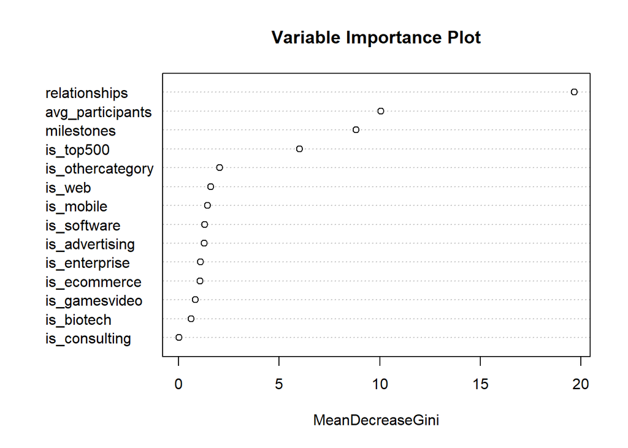

```r
varImpPlot(rf1_test, main = "Variable Importance Plot")
```

> Relationships, avg_participants, milestones and is_top500 are most important.

## Results and Dissussion

> The results indicate that startup success can be predicted with reasonable accuracy using machine learning techniques. Important features identified in the analysis provide insights into factors that contribute to startup success. Further research could explore additional features and models to improve predictive performance.